# Unit 03 Project

Khushi Patel

2026-02-12

# Part I: Morphological Data

## Question 1

```r
iris %>%
group_by(Species) %>%
summarise(across(where(is.numeric), mean))
```

```
## # A tibble: 3 × 5
##   Species    Sepal.Length Sepal.Width Petal.Length Petal.Width
##   <fct>             <dbl>       <dbl>        <dbl>       <dbl>
## 1 setosa             5.01        3.43         1.46       0.246
## 2 versicolor         5.94        2.77         4.26       1.33
## 3 virginica          6.59        2.97         5.55       2.03
```

## Question 2

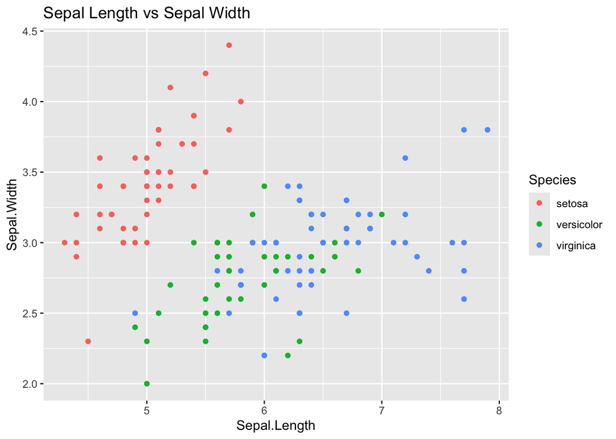

```r
ggplot(iris, aes(x=Sepal.Length, y=Sepal.Width, color=Species))+
  geom_point() +
  labs(title = "Sepal Length vs Sepal Width")
```

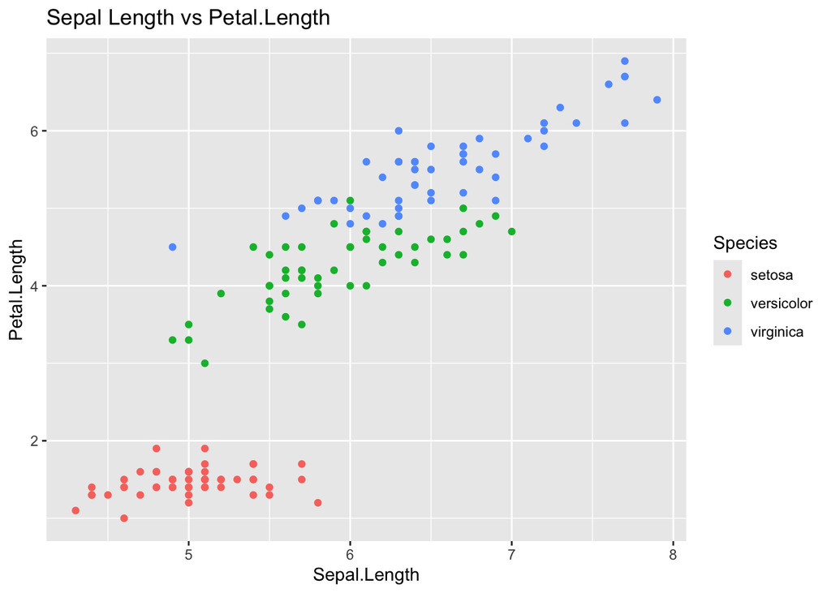

```r
ggplot(iris, aes(x=Sepal.Length, y=Petal.Length, color=Species))+
  geom_point() +
  labs(title = "Sepal Length vs Petal.Length")
```

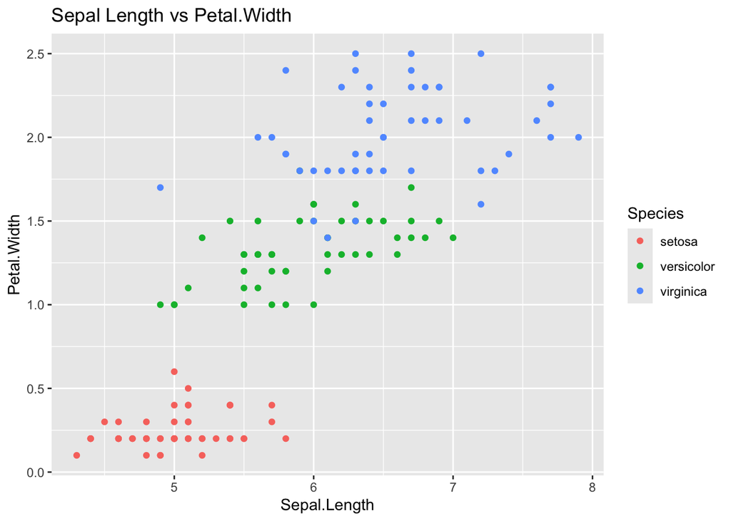

```r
ggplot(iris, aes(x=Sepal.Length, y=Petal.Width, color=Species))+
  geom_point() +
  labs(title = "Sepal Length vs Petal.Width")
```

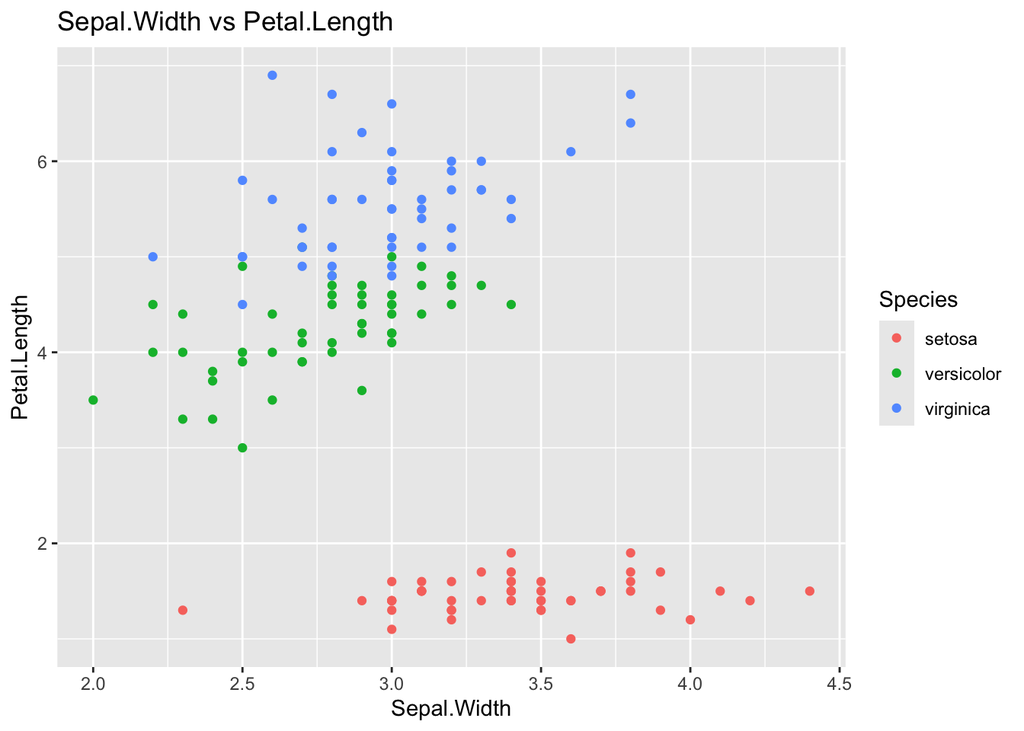

```r
ggplot(iris, aes(x=Sepal.Width, y=Petal.Length, color=Species))+
  geom_point() +
  labs(title = "Sepal.Width vs Petal.Length")
```

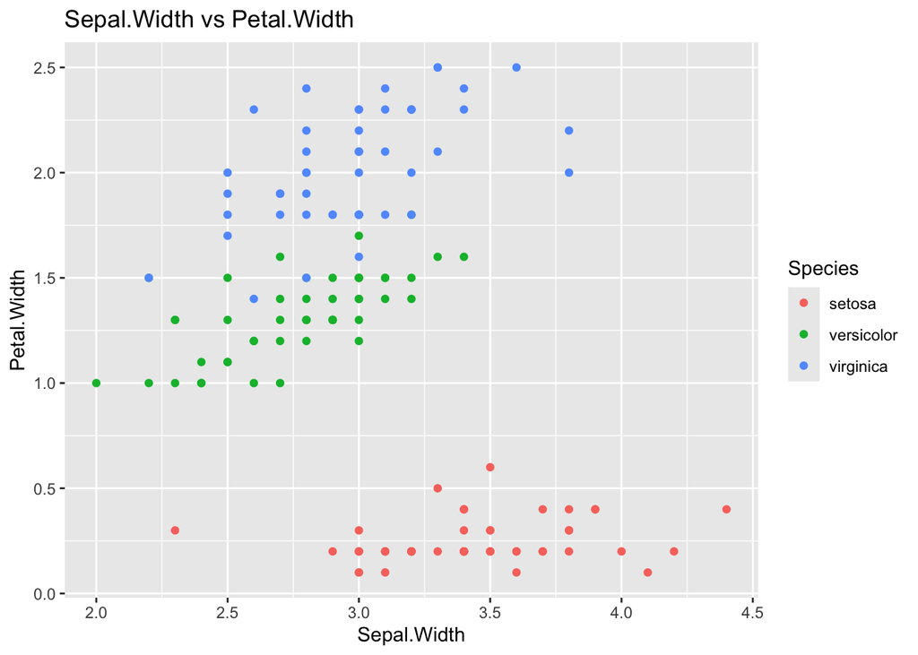

```r
ggplot(iris, aes(x=Sepal.Width, y=Petal.Width, color=Species))+
  geom_point() +
  labs(title = "Sepal.Width vs Petal.Width")
```

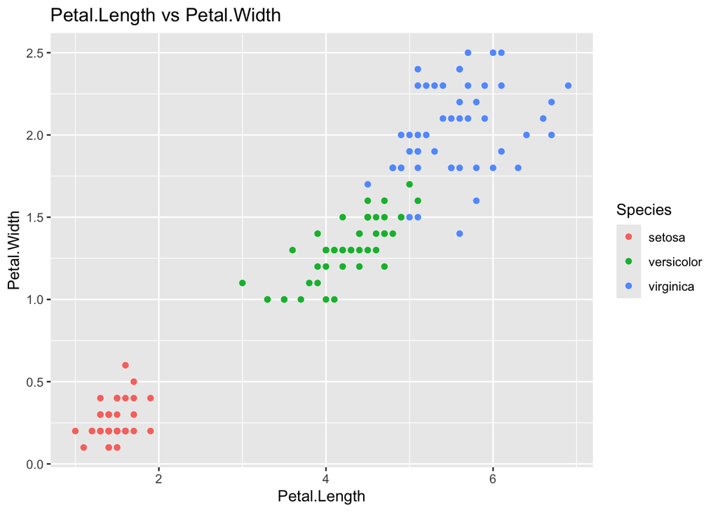

```r
ggplot(iris, aes(x=Petal.Length, y=Petal.Width, color=Species))+
  geom_point() +
  labs(title = "Petal.Length vs Petal.Width")
```

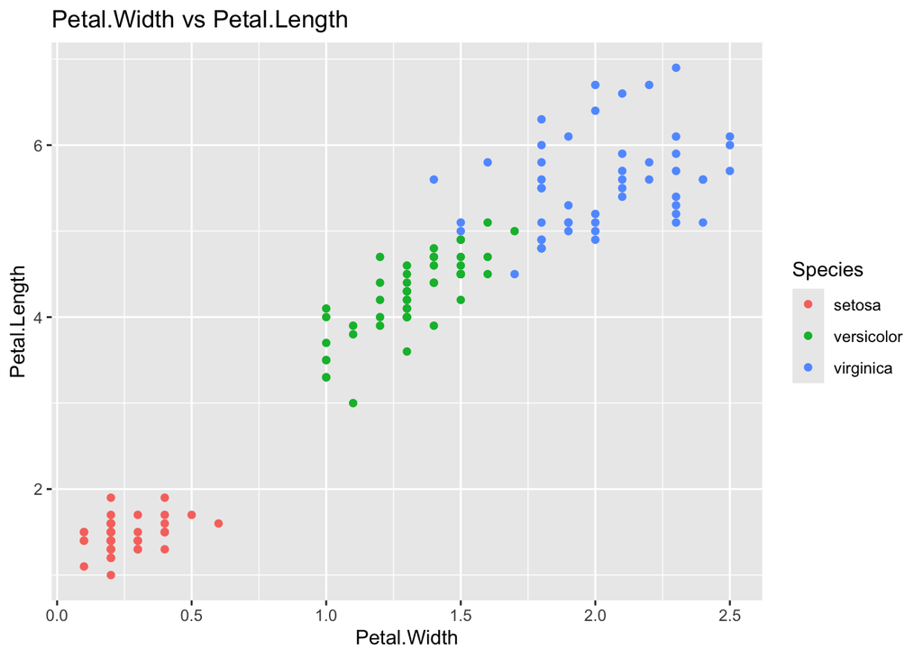

```r
ggplot(iris, aes(x=Petal.Width, y=Petal.Length, color=Species))+
  geom_point() +
  labs(title = "Petal.Width vs Petal.Length")
```

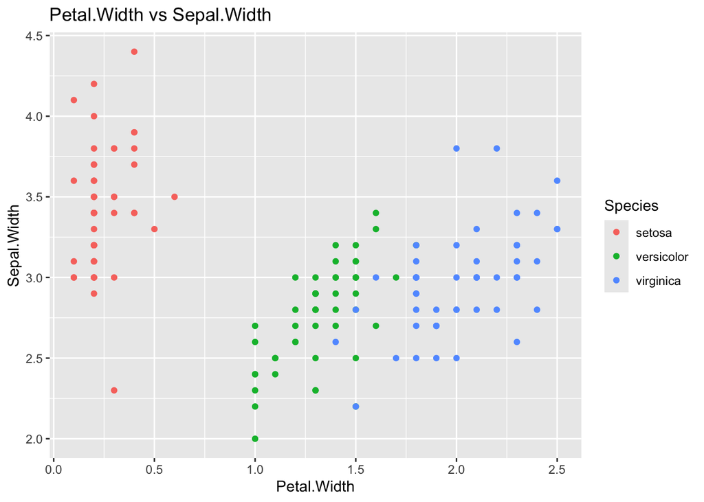

```r
ggplot(iris, aes(x=Petal.Width, y=Sepal.Width, color=Species))+
  geom_point() +
  labs(title = "Petal.Width vs Sepal.Width")
```

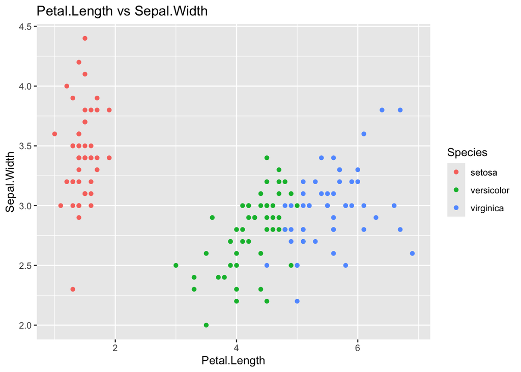

```r
ggplot(iris, aes(x=Petal.Length, y=Sepal.Width, color=Species))+
  geom_point() +
  labs(title = "Petal.Length vs Sepal.Width")
```

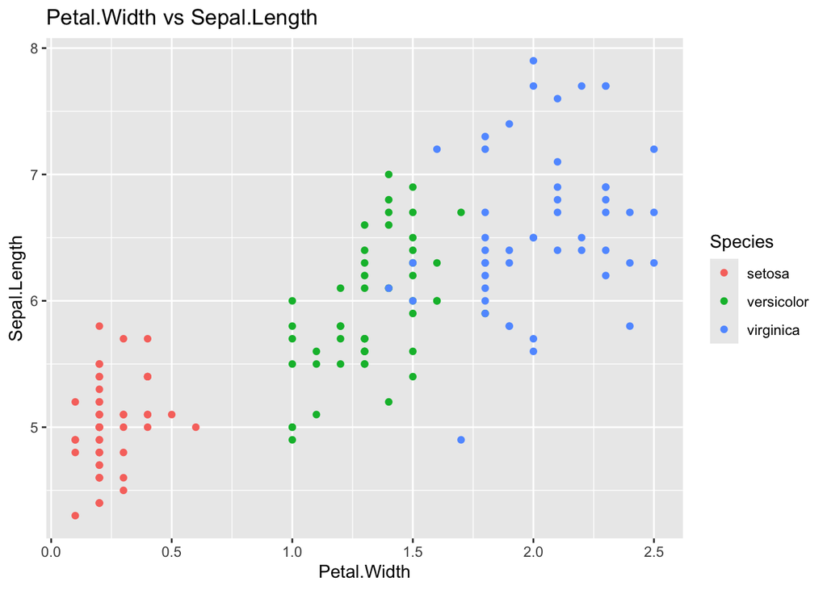

```r
ggplot(iris, aes(x=Petal.Width, y=Sepal.Length, color=Species))+
  geom_point() +
  labs(title = "Petal.Width vs Sepal.Length")
```

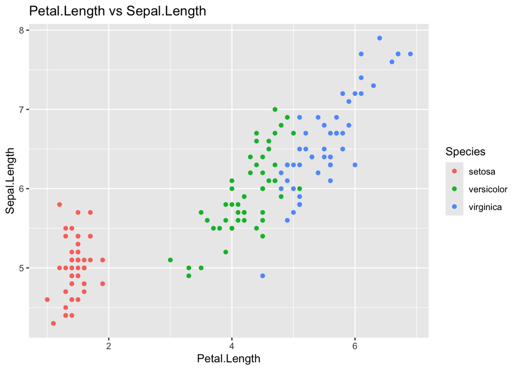

```r
ggplot(iris, aes(x=Petal.Length, y=Sepal.Length, color=Species))+
  geom_point() +
  labs(title = "Petal.Length vs Sepal.Length")
```

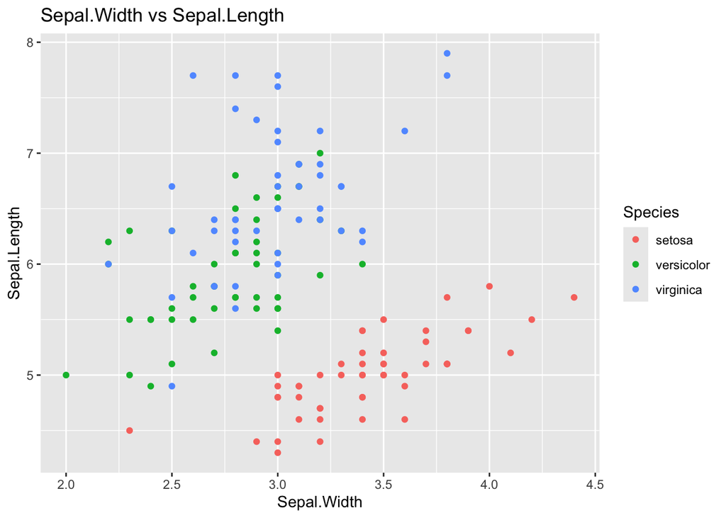

```r
ggplot(iris, aes(x=Sepal.Width, y=Sepal.Length, color=Species))+
  geom_point() +
  labs(title = "Sepal.Width vs Sepal.Length")
```

```r
library(MASS)
DATA<-iris %>%
  dplyr::select(Petal.Length,Petal.Width)

group <-iris %>%
  pull(Species)
fit<-lda(DATA, group)
pred<-predict(fit, DATA)$class
table(iris$Species,pred)
```

```
##             pred
##              setosa versicolor virginica
##   setosa         50          0         0
##   versicolor      0         48         2
##   virginica       0          4        46
```

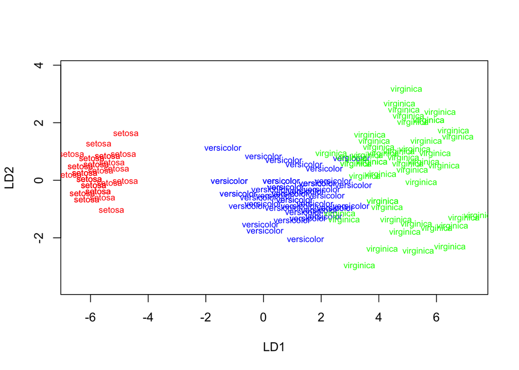

```r
plot(fit, col=c("red","blue","green")[unclass(group)])
```

```r
DATA2<-iris %>%
  dplyr::select(Petal.Length,Sepal.Length)

group <-iris %>%
  pull(Species)
fit2<-lda(DATA2, group)
pred2<-predict(fit2, DATA2)$class
table(iris$Species,pred2)
```

```
##             pred2
##              setosa versicolor virginica
##   setosa         50          0         0
##   versicolor      0         48         2
##   virginica       0          3        47
```

```r
plot(fit, col=c("red","blue","green")[unclass(group)])
```

[output not shown]

## Question 4

#I used the discriminant analysis results and confusion table to see the measurements of the predicted species. The petal length and petal width were correct predictions so I am sure about Anderson’s predictions even though there is only a little overlap.

# Part II: Geographical and temporal data

```r
library(dismo)

get.gbif <- function(genus, species, na.rm = TRUE, crop = TRUE) {

    gps <- gbif(genus, species, geo = FALSE)

    if (na.rm) {
        gps <- subset(gps, !is.na(lon) & !is.na(lat))
    }
    if (crop) {
        keep <- c(which(colnames(gps) == "species"), which(colnames(gps) == "lat"), which(colnames(gps) == "lon"), which(colnames(gps) ==
            "month"))
        gps <- gps[keep]
    }
    return(gps)
}


iris_gps <- read_csv("iris_gps.csv")
```

## Question 1

#The Fennec Fox is primarily located in North Africa.

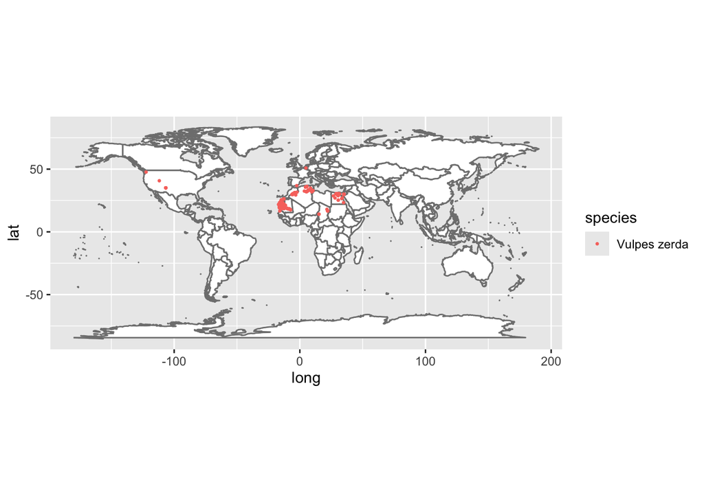

```r
library(dismo)
library(dplyr)
library(ggplot2)
library(maps)


Fennec_Fox <- get.gbif("Vulpes","zerda")

world.map <- map_data(map = "world")
us.map <- map_data(map = "usa")

ggplot(world.map, aes(long, lat, group = group)) + geom_polygon(fill = "white", colour = "grey50") + coord_quickmap() + geom_point(data = Fennec_Fox,
    mapping = aes(x = lon, y = lat, group = species, color = species), size = 0.5)
```

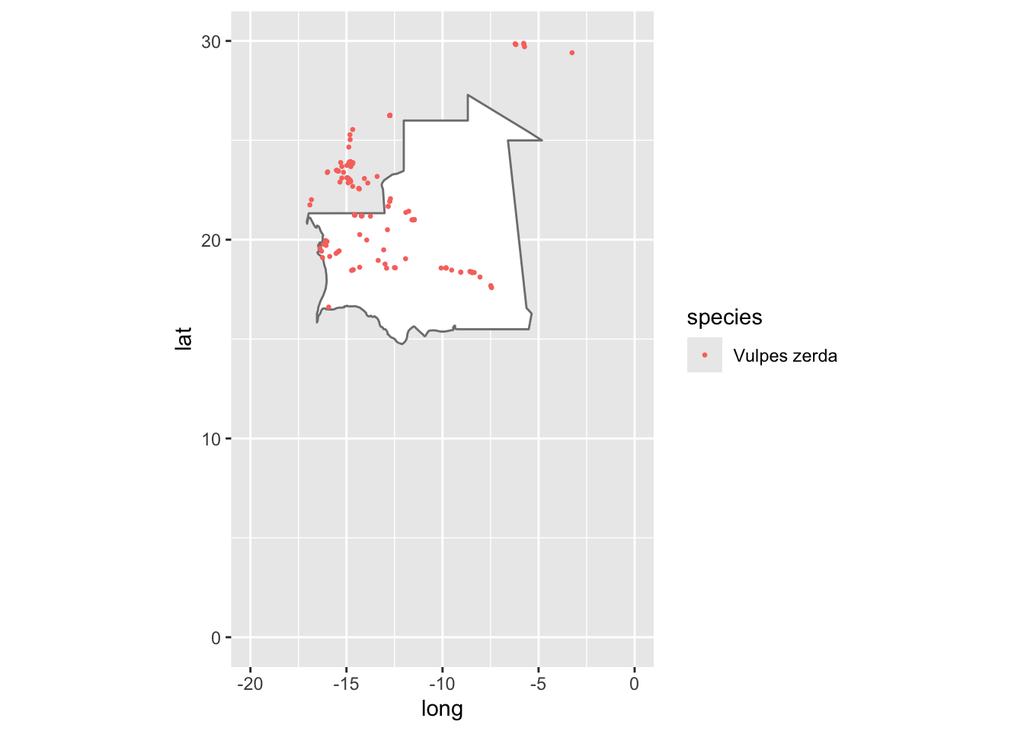

```r
Fennec_Fox_map <- map_data(map = "world",region="mauritania")
ggplot(Fennec_Fox_map, aes(long, lat, group = group)) + geom_polygon(fill = "white", colour = "grey50") + coord_quickmap() + geom_point(data = Fennec_Fox,
    mapping = aes(x = lon, y = lat, group = species, color = species), size = 0.5) +
  xlim(-20,0) +
  ylim(0,30)
```

## Question 2

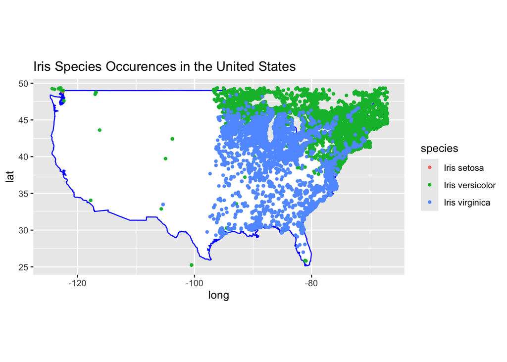

```r
library(maps)
us.map <- map_data(map="usa")
min_lon <- min(us.map$long)
max_lon <- max(us.map$long)

min_lat <- min(us.map$lat)
max_lat <- max(us.map$lat)

iris_usa <- iris_gps %>%
  filter(lon >= min_lon, lon<=max_lon,
         lat>=min_lat, lat<=max_lat)
ggplot(us.map, aes(long, lat, group=group)) +
  geom_polygon(fill="white", colour="blue")+
  coord_quickmap()+
  geom_point(data=iris_usa,
             mapping = aes(x=lon,y=lat, group=species,color= species),
             size=1) +
  labs(title = "Iris Species Occurences in the United States")
```

## Question 3 ?

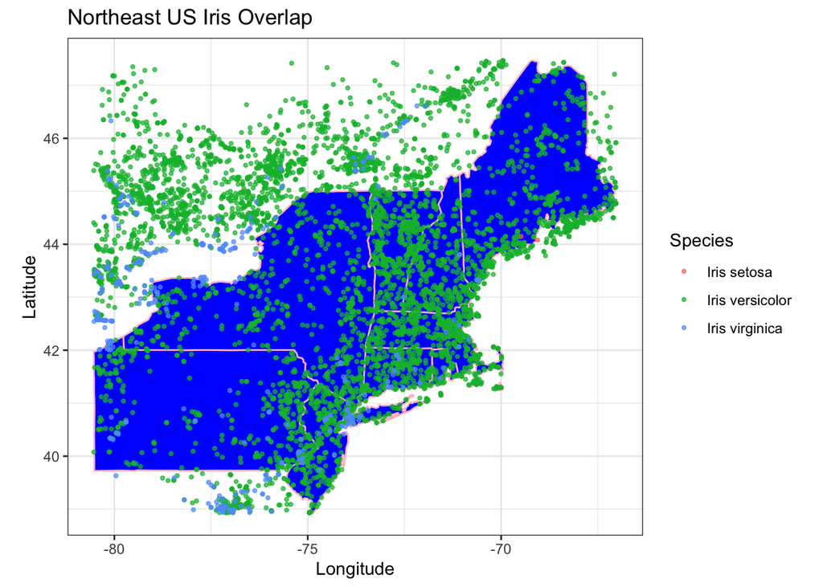

```r
library(dplyr)
library(ggplot2)
library(maps)

ne_states <- c("maine","new hampshire","vermont", "massachusetts","rhode island","connecticut","new york", "new jersey", "pennsylvania")
ne.map <- map_data("state") %>%
  filter(region %in% ne_states)

min_lon <- min(ne.map$long, na.rm = TRUE)
max_lon <- max(ne.map$long, na.rm = TRUE)
min_lat<-min(ne.map$lat, na.rm = TRUE)
max_lat<-max(ne.map$lat, na.rm = TRUE)

iris_ne <- iris_gps %>%
  filter(lon>= min_lon, lon<=max_lon,
         lat>=min_lat, lat<=max_lat)
grid_size<- 0.5
iris_ne_grid <- iris_ne %>%
  mutate(
    lon_bin=floor(lon/grid_size)*grid_size,
    lat_bin=floor(lat/grid_size)*grid_size)
overlap_ne<- iris_ne_grid %>%
  group_by(lon_bin, lat_bin)%>%
  summarize(n_species=n_distinct(species), groups="drop")%>%
  filter(n_species==3)

saveRDS(overlap_ne, "overlap_ne.rds")
write.csv(overlap_ne, "overlap_ne.csv", row.names = FALSE)

ggplot() +
  geom_polygon(
    data = ne.map,
    aes(x = long, y = lat, group = group),
    fill = "blue",
    color = "pink"
  ) +
  geom_point(
    data = iris_ne,
    aes(x = lon, y = lat, color = species),
    alpha = 0.7,
    size = 0.8
  ) +

  geom_tile(
    data = overlap_ne,
    aes(x = lon_bin + grid_size/2, y = lat_bin + grid_size/2),
    width = grid_size,
    height = grid_size,
    fill = NA,
    color = "white",
    linewidth = 1
  ) +
  coord_quickmap(xlim = c(min_lon, max_lon), ylim = c(min_lat, max_lat)) +
  theme_bw() +
  labs(
    title = "Northeast US Iris Overlap",
    x = "Longitude", y = "Latitude", color = "Species"
  )
```

## Question 4 #The distribution of the three species in the US is mainly in the Northeast while Iris Virginica is in the Eastern and Central US, and Iris Versicolor is mostly in the Northeast.All three species overlap in the Northeast region of the US. #This exercise showed that the species are not very allopatric since there is overlap of the three species. Iris setosa is mainly in the far North, Iris Versicolor is the Northeast, and Iris Virginica is found mainly throughout the Eastern and Central US. #The Northeast overlap shows current delineations while alsp proving that Iris versicolor is a hybrid species since it is from the other two together.The closeness is for natural breeding to occur which Anderson said as well how versicolor is from diplod setosa and tetraploid virginca.

## Question 5

#Using observation months can have problems since it doesn’t have the specific flowering period so its hard to figure out temporal isolation.Also there could be bias from human observation.

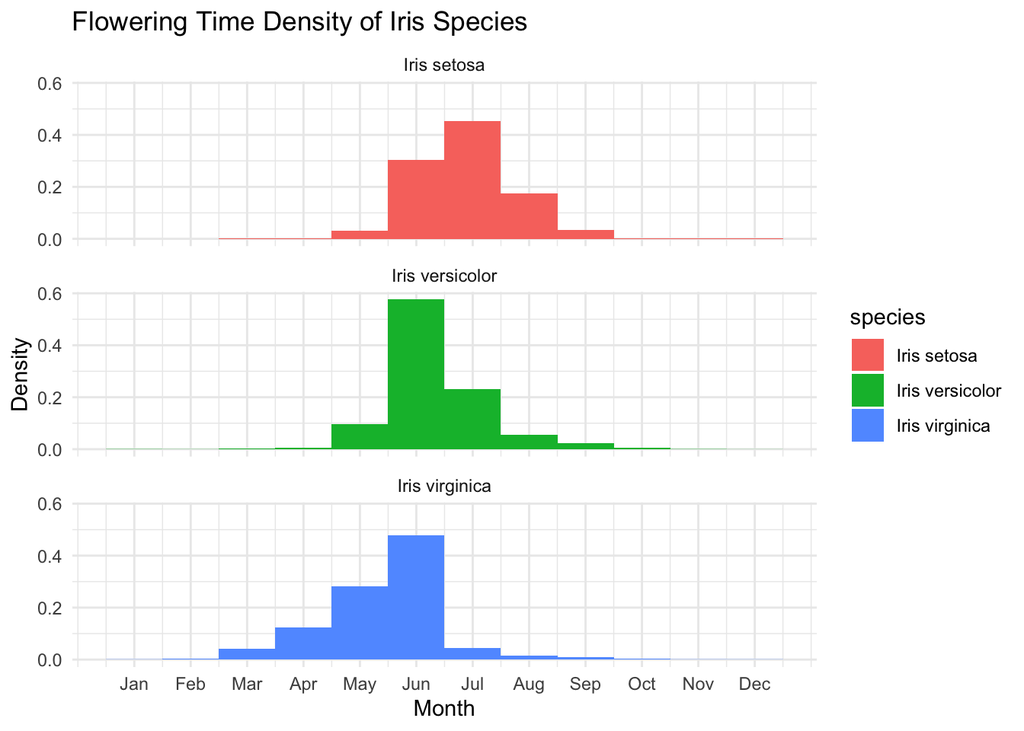

```r
month_labels <- c("Jan", "Feb", "Mar", "Apr", "May", "Jun", "Jul", "Aug", "Sep", "Oct", "Nov", "Dec")

ggplot(data=iris_gps, aes(x=month, y=after_stat(density), group=species, fill=species))+
  geom_histogram(position="dodge", binwidth=1)+
  facet_wrap(~species, nrow=3)+
  scale_x_continuous(breaks=1:12, labels=month_labels)+
  theme_minimal()+
  labs(title = "Flowering Time Density of Iris Species",
       x="Month",
       y="Density")
```

# Part III: Chromosomal data

## Question 1

```r
library(tidyverse)

iris_chrom_dataset<- read_csv("iris_chromosomes.csv", skip=1, col_names=T,trim_ws = T,skip_empty_rows = T)

iris_chrom <- iris_chrom_dataset %>%
    dplyr::select(resolved_name, sporophytic, parsed_n) %>%
    separate(resolved_name, into = c("genus", "species"), sep = " ", remove = TRUE, extra = "drop")
iris_chrom<-drop_na(iris_chrom)

iris_chrom <- iris_chrom %>%
  mutate(sporophytic_clean = str_replace_all(iris_chrom$sporophytic, "2n =", ""))

iris_chrom <- iris_chrom %>%
  dplyr::select(-sporophytic)

iris_chrom <- iris_chrom %>%
  mutate(good = str_detect(sporophytic_clean, "^...$|^..$"))

iris_good <- iris_chrom %>% filter(good == T)
iris_bad <- iris_chrom %>% filter(good == F)

iris_commas <- iris_bad %>%
  filter(str_detect(sporophytic_clean, ",") == T)

iris_commas_clean <-iris_commas %>%
    slice(-10, -11, -12, -32, -44, -46, -49, -55, -58, -63) %>%
    separate_longer_delim(c(sporophytic_clean, parsed_n), delim = ",")

iris_other <- iris_bad %>%
  filter(str_detect(sporophytic_clean, ",") == F)

clean_iris_chrom <- bind_rows(iris_good, iris_commas_clean) %>%
  dplyr::select(-good)

clean_iris_chrom$sporophytic_clean <- as.numeric(clean_iris_chrom$sporophytic_clean)
clean_iris_chrom$parsed_n <- as.numeric(clean_iris_chrom$parsed_n)

str(clean_iris_chrom)
```

```
## tibble [1,240 × 4] (S3: tbl_df/tbl/data.frame)
##  $ genus            : chr [1:1240] "Iris" "Iris" "Iris" "Iris" ...
##  $ species          : chr [1:1240] "acutiloba" "acutiloba" "acutiloba" "acutiloba" ...
##  $ parsed_n         : num [1:1240] 10 10 10 10 10 10 10 10 11 11 ...
##  $ sporophytic_clean: num [1:1240] 20 20 20 20 20 20 20 20 22 22 ...
```

```r
Mode_func<- function(x){
  ux<- unique(x)
  ux[which.max(tabulate(match(x,ux)))]}

clean_iris_chrom_modes <- clean_iris_chrom %>% group_by(species) %>% summarize(across(where(is.numeric), Mode_func))

print(clean_iris_chrom_modes, n = 20)
```

```
## # A tibble: 211 × 3
##    species        parsed_n sporophytic_clean
##    <chr>             <dbl>             <dbl>
##  1 acutiloba            10                20
##  2 afghanica            11                22
##  3 aitchisonii          17                34
##  4 alberti              12                24
##  5 albicans             22                44
##  6 albomarginata        25                50
##  7 anguifuga            17                34
##  8 antilibanotica       10                20
##  9 aphylla              24                48
## 10 arenaria             11                22
## 11 assadiana            10                20
## 12 atrofusca            10                20
## 13 atropatana            9                18
## 14 atropurpurea         10                20
## 15 aucheri              12                24
## 16 auranitica           10                20
## 17 barnumiae            10                20
## 18 basaltica            10                20
## 19 bicapitata           20                40
## 20 biglumis             20                40
## # ℹ 191 more rows
```

## Question 2

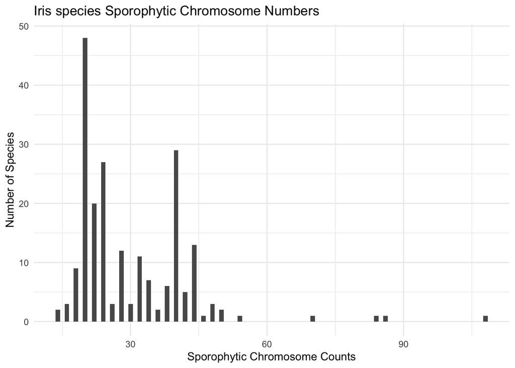

```r
ggplot(data = clean_iris_chrom_modes, aes(x = sporophytic_clean, group = species)) +
  geom_histogram(binwidth = 1) +
  theme_minimal() +
  labs(x = "Sporophytic Chromosome Counts", y = "Number of Species", title = "Iris species Sporophytic Chromosome Numbers")
```

## Question 3 Further proof versicolor is a hybrid of setosa (38) and virginica (70) is because when you add the modes of both they equal 108 which is the mode of versicolor.

```r
clean_iris_chrom_modes %>%
  slice(166, 197, 199)
```

```
## # A tibble: 3 × 3
##   species    parsed_n sporophytic_clean
##   <chr>         <dbl>             <dbl>
## 1 setosa           19                38
## 2 versicolor       54               108
## 3 virginica        35                70
```

# Part IV: Producing a scientific argument

## Question 1

#Geographically Virginica and Versicolor overlap in the Northeast which show that they have similar environmental constraints to survive.Setosa is separated from the other two.

#Versicolor is a hybrid of setosa (38) and virginica (70) is because when you add the modes of chromosomes they equal 108 which is the mode of versicolor.

#The most compelling is chromosomal data because when you add the modes of chromosomes virginica and setosa they equal 108 which is the mode of versicolor.

#I think Anderson was correct. Isolation could be because of morphological or chromosomal number.

#I believe these organisms represent one species because while they do connect to make versicolor they still come from each other and have similar attribute. I think of it like this where a child has attributes from both their parents no matter where they lived previously geographically but in the end they are all still human just like they are all still iris.